# 04 OS Open Greenspace Spatial Distirbution

Analysing the spatial distribution of OS Open Greenspace.

```r
library(sf)
library(tmap)
library(maptiles)
```

## Create an `sf` object from GeoPackage (GPKG)

Repeat the initial steps from the last notebook to load the Greenspace GeoPackage.

```r
# Create an sf data.frame object from the Greenspace file
osogs <- st_read('../../data/ordnance-survey/os-open-greenspace-gb.gpkg',
                 layer = 'greenspace_site')
```

## Plot `sf` data frame

Visualising a dataset of relatively small MULTIPOLYGON geometries at a GB (small) scale can pose a challenge. If the data is plotted against a white background it can be difficult to interpret the spatial distribution.

Changing the geometry type of the dataset or increasing the contrast between the data overlay and the basemap can produce a cleareer output. Deriving the centroid POINT geometry of each feature offers a solution as marker size adjustments can make features larger and clearer on the map.

The three example plots below explore different styles. Which do you think is most effective?

## Plot A

- No change to source MultiPolygon geometry.
- White background.

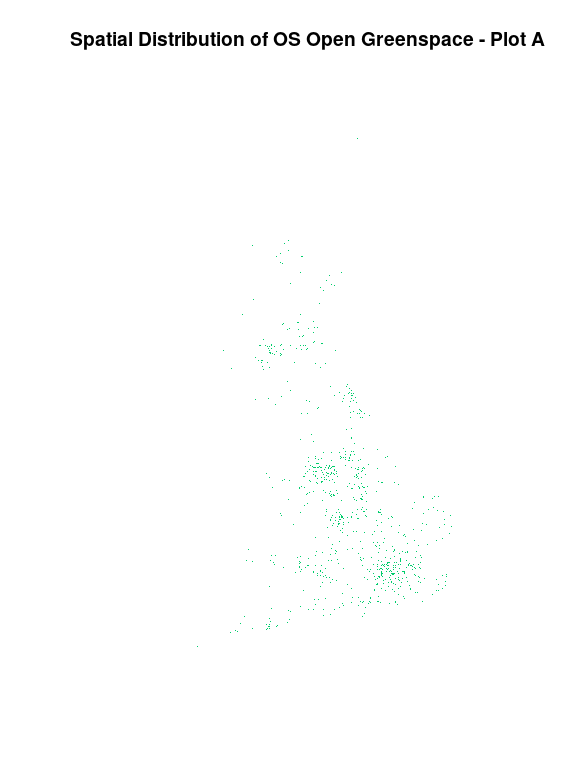

```r
# Basic map using built-in plotting functionality
# Note: st_* call to retrieve just the geometry column
plot(st_geometry(osogs),
     col = '#00cd6c',
     border = NA,
     main = 'Spatial Distribution of OS Open Greenspace - Plot A')
```

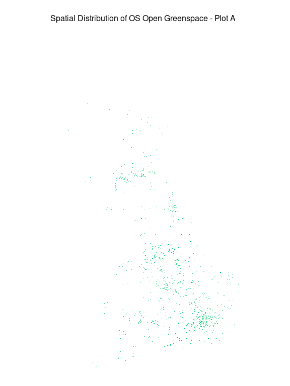

```r
# Basic map using tmap's "Quick Thematic Map" functionality
qtm(osogs,
    fill = '#00cd6c',
    borders = NULL,
    frame = FALSE,
    title = 'Spatial Distribution of OS Open Greenspace - Plot A')
```

### Plot B

- Source MultiPolygon geometry converted to centroid Point geometry.
- White background.
- Marker size and opacity can be flexed to accommodate feature density and distribution.

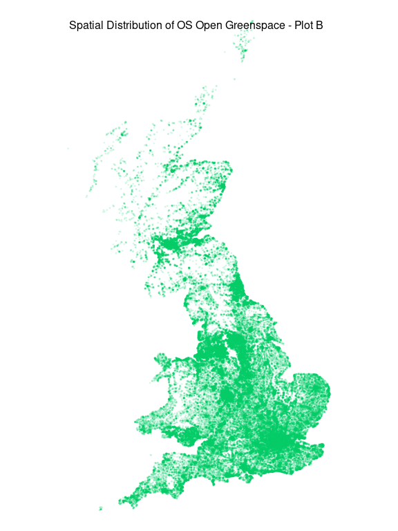

```r
# Centroid map using tmap functionality
tm_shape(st_centroid(osogs)) +
  tm_dots(col = '#00cd6c',
          alpha = 0.1) +
  tm_layout(frame = FALSE,
            title = 'Spatial Distribution of OS Open Greenspace - Plot B')
```

```r
# dots are same size - no info on area
```

### Plot C

- Source MultiPolygon geometry converted to centroid Point geometry.
- Feature colour selected to contrast with background.
- Marker size and opacity can be flexed to accommodate feature density and distribution.

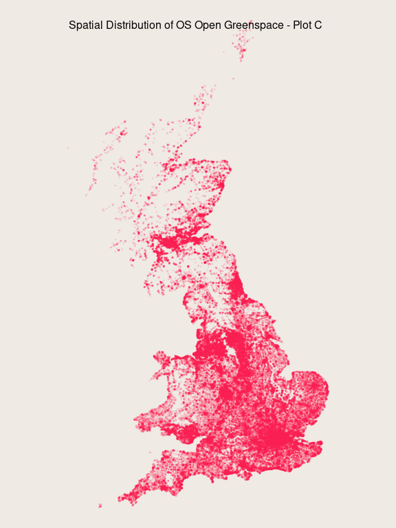

```r
# Centroid map using tmap functionality
tm_shape(st_centroid(osogs)) +
  tm_dots(col = '#ff1f5b',
          alpha = 0.1) +
  tm_layout(bg.color = '#efeae4',
            frame = FALSE,
            title = 'Spatial Distribution of OS Open Greenspace - Plot C')
```

## Spatially subset data frame

Using coordinates to spatially subset by bounding box (BBOX).

```r
# Subset the data by intersection with BBOX

# Greater London bounding box
bbox <- st_bbox(c(xmin = 503568.1996,
                  xmax = 561957.4962,
                  ymin = 155850.7975,
                  ymax = 200933.9026),
                crs = st_crs(27700))

# Convert into a 'geometry'
bbox <- st_as_sfc(bbox)

# Spatial subsetting/filtering
osogs_filtered <- osogs[bbox, ]
```

```r
nrow(osogs_filtered)
```

```
[1] 12529
```

```r
# Reproject to Web Mercator (EPSG: 3857)
# Prepare for basemap tiles
osogs_filtered <- st_transform(osogs_filtered, crs = 3857)
```

## Add OS Maps API base map to `tmap` plot

```r
# OS Maps API layer
# Example uses Light Style in Web Mercator (EPSG:3857) projection
layer <- 'Light_3857'

# OS Data Hub project API key
key <- '7UTXMMWsGjjIzcBmLdAGnMO6WEAQi9Ng'

# OS Data Hub base path - https://api.os.uk
# OS Maps API ZXY endpoint path - /maps/raster/v1/zxy/
url <- paste0('https://api.os.uk/maps/raster/v1/zxy/', layer,
              '/{z}/{x}/{y}.png?key=XXXXXX')  # Note the placeholder key
```

```r
# Define the tile server parameters for maptiles
osmaps <- list(src = 'OS Maps',
               q = url,
               sub = '',
               cit = paste0('Contains OS data © Crown copyright and database rights ',
                            format(Sys.Date(),"%Y"), '.'))
```

```r
# Download tiles and compose base map raster
tile_maps <- get_tiles(x = st_bbox(osogs_filtered),
                       provider = osmaps,
                       zoom = 10,  # If omitted, will search for 'best' zoom
                       crop = TRUE,
                       cachedir = tempdir(),  # Where to store the download
                       apikey = key,
                       verbose = FALSE)
```

## Plot subplots showing the spatial distribution by function

Visualise the spatial distribution of OS Open Greenspace features by function using subplots.

```r
# Subset features to exclude some functions
osogs_filtered <- osogs_filtered[!osogs_filtered$function. %in% c('Play Space',
                                                                  'Tennis Court'), ]

# Return unique functions
unique(osogs_filtered$function.)
```

```
[1] "Allotments Or Community Growing Spaces" "Bowling Green"
[3] "Playing Field"                          "Public Park Or Garden"
[5] "Cemetery"                               "Other Sports Facility"
[7] "Religious Grounds"                      "Golf Course"
```

```r
length(unique(osogs_filtered$function.))
```

```
[1] 8
```

## OS GeoDataViz colour palettes

The OS [GeoDataViz toolkit](https://github.com/OrdnanceSurvey/GeoDataViz-Toolkit/tree/master/Colours) provides qualitative, sequential, and diverging colour palettes to support GDV applications.

```r
# OS GDV qualitative colour palette
colours <- c('#FF1F5B','#00CD6C','#009ADE','#AF58BA',
             '#FFC61E','#F28522','#A0B1BA','#A6761D')
```

```r
length(colours)
```

```
[1] 8
```

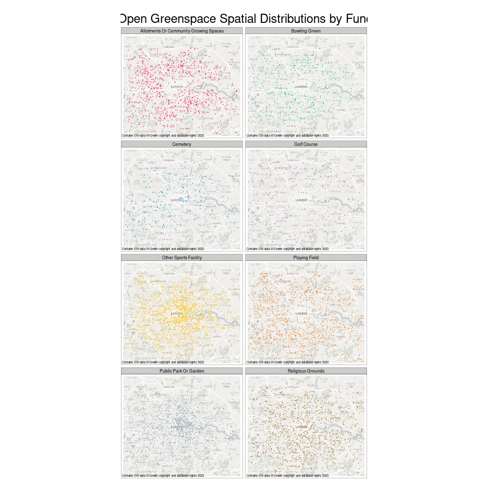

```r
# Create figure and subplots

# basemap layer
base <- tm_shape(tile_maps,
                 bbox = st_bbox(tile_maps)) +
          tm_rgb() +
          tm_credits(osmaps$cit,
                     position = c("LEFT", "BOTTOM"))

# plot sf
base +
tm_shape(st_centroid(osogs_filtered)) +
  tm_dots(col = 'function.',
          palette = colours,
          legend.show = FALSE) +
  tm_layout(main.title = 'OS Open Greenspace Spatial Distributions by Function',
            main.title.position = 'center') +
  tm_facets(by = 'function.',
            ncol = 2)
```